# Flooded Land Inventory Estimate for Louisiana

J. Beaulieu

2021-05-18

## 0.1 Setup

```r
library(tidyverse)
library(sf)
library(USAboundaries)
library(lwgeom)
library(kableExtra)

# Print R session info
```

## 0.2 Louisiana Flooded Lands

Flooded Lands in the US are derived from the [U.S. Army Corps of Engineers National Inventory of Dams](https://nid.sec.usace.army.mil/ords/f?p=105:1::::::), Navigable Waterways dataset maintained by the Department of Homeland security, and the [National Hydrography Data (NHD)](https://www.usgs.gov/core-science-systems/ngp/national-hydrography) maintained by the USGS. Several screening tools were used to discriminate natural water bodies from Flooded Lands in these data sets.

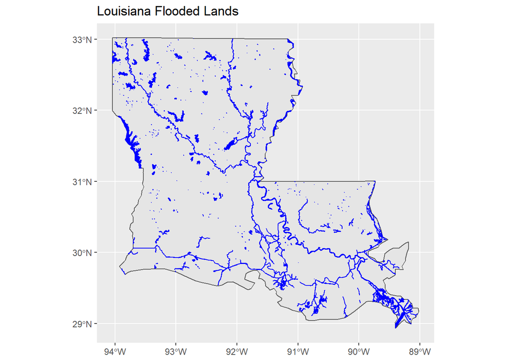

```r
# read data from local sources
inund <- sf::st_read(paste0("C:\\Users\\JBEAULIE\\Environmental Protection Agency (EPA)\\",
                            "SuRGE Survey of Reservoir Greenhouse gas Emissions - Documents\\",
                            "surgeDsn\\nationalFloodedLandsMapping\\Reservoir Data\\Data.gdb"),
                     layer = "InundationArea")
st_crs(inund) # 4269

nav <- sf::st_read(paste0("C:\\Users\\JBEAULIE\\Environmental Protection Agency (EPA)\\",
                            "SuRGE Survey of Reservoir Greenhouse gas Emissions - Documents\\",
                            "surgeDsn\\nationalFloodedLandsMapping\\Reservoir Data\\Data.gdb"),
                     layer = "Navigable_Waterways")
st_crs(nav) #4269

less8 <- sf::st_read(paste0("C:\\Users\\JBEAULIE\\Environmental Protection Agency (EPA)\\",
                            "SuRGE Survey of Reservoir Greenhouse gas Emissions - Documents\\",
                            "surgeDsn\\nationalFloodedLandsMapping\\Reservoir Data\\Data.gdb"),
                     layer = "Reservoirs_Less8ha") %>%
  st_transform(4269)

great8 <- sf::st_read(paste0("C:\\Users\\JBEAULIE\\Environmental Protection Agency (EPA)\\",
                            "SuRGE Survey of Reservoir Greenhouse gas Emissions - Documents\\",
                            "surgeDsn\\nationalFloodedLandsMapping\\Reservoir Data\\Data.gdb"),
                     layer = "Reservoirs_Greater8ha")  %>%
  st_transform(4269)


# get state boundary
la <- us_states() %>% # get states map
  filter(name == "Louisiana") %>%
  st_transform(4269) # 4269, as above

# clip waterbodies to state
la.inund <- sf::st_intersection(x = inund, y = la)
la.nav <- sf::st_intersection(x = nav, y = la)
la.less8 <- sf::st_intersection(x = less8, y = la)
la.great8 <- sf::st_intersection(x = great8, y = la)



ggplot() +
  geom_sf(data = la) +
  geom_sf(data = la.inund, color = "blue", fill = "blue") +
  geom_sf(data = la.nav, color = "blue", fill = "blue") +
  geom_sf(data = la.less8, color = "blue", fill = "blue") +
  geom_sf(data = la.great8, color = "blue", fill = "blue") +
  ggtitle("Louisiana Flooded Lands")
```

## 0.3 GHG Emissions and Removals from Louisiana Flooded Lands

```r
# surface area and emissions
sa <- data.frame(type = c("Flooded Lands", "Ponds"),
                 area.m2 = c(st_area(la.inund) %>% sum() %>% as.numeric() +
                               st_area(la.nav) %>% sum() %>% as.numeric() +
                               st_area(la.great8) %>% sum() %>% as.numeric(),
                             st_area(la.less8) %>% sum() %>% as.numeric())
) %>%
  mutate(area.ha = round(area.m2 / 10000, digits = 0), # convert to hectares
         ch4Emission = ifelse(type == "ponds",
                              area.ha * 183, # table 7.12
                              area.ha * 141.1), # table 7.9
         dnStream = ch4Emission * 0.09,
         totalCh4 = ch4Emission + dnStream) %>%
  select(-area.m2)
```

We assume that all Louisiana Flooded Lands are greater than 20 years old and thus classified as ‘Flooded Lands Remaining Flooded Lands’. Only CH<sub>4</sub> emissions are inventoried for this managed lands category, whereas CO<sub>2</sub> emissions are also inventoried for Flooded Lands less than 20 years old. Nitrous oxide emissions are not accounted here, but are captured in other IPCC methodologies.

```r
sa %>% kbl(caption = "Surface area and annual CH4 emissions for Louisiana Flooded Lands",
           col.names = c("Flooded Lands Type", "Surface area (Ha)", "Surface emissions (kg CH4/year)",
                         "Downstream emissions (kg CH4/year)", "Total emissions (kg CH4/year)"),
           format.args = list(big.mark = ",")) %>%
  kable_classic()
```

Surface area and annual CH4 emissions for Louisiana Flooded Lands

| Flooded Lands Type | Surface area (Ha) | Surface emissions (kg CH4/year) | Downstream emissions (kg CH4/year) | Total emissions (kg CH4/year) |
| --- | --- | --- | --- | --- |
| Flooded Lands | 281,484 | 39,717,392.4 | 3,574,565.32 | 43,291,958 |
| Ponds | 1,025 | 144,627.5 | 13,016.48 | 157,644 |